# Stock returns

Juan Carlos Martínez-Ovando

jc-mo@tec.mx

Febrero-Junio 2020

# 1 Objetives

- In this session we shall learn to access financial data from APIs using `R`.
- We shall learn to manipulate financial data recorded over time.
- We will learn to visualize and summarize financial data and returns.

# 2 Stock data

Stock and investments analysis is a theme that can be deeply explored in programming. This includes `R` language, which already has a big literature, packages and functions developed in this matter. We shall do a brief introduction to the subject using the packages `quantmod` and `ggplot2`.

The illustration will be developed analyzing the `PBR` series, from the brazilian company **Petrobras**, with data extracted from **Yahoo! Finance** using the package `quantmod`. The package `quantmod` is a well known package used to quantitave financial modelling. Also, we’ll use the package `ggplot2` for data visualization.

# 3 Environment

The first thing to do is to set the environment, which is quite simple. Firstly, we install and load the necessary packages.

```r
if(!require("quantmod")){install.packages("quantmod")}
```

```
## Version 0.4-0 included new data defaults. See ?getSymbols.
```

```r
if(!require("ggplot2")){install.packages("ggplot2")}
library("quantmod")
library("ggplot2")
```

It’s important to highlight that we only install the packages once. In the next times we run the code, it’ll be necessary only to load them using the `library` command.

After installing and loading the packages, now we’ll download the stock prices series and treat the data in order to get them in the best possible format for the analysis. We download the data using the function `getSymbols` (`Symbols` are refered to the financial objects containing the data set of historical stock prices).

```r
pbr <- getSymbols("PBR",
                  src = "yahoo",
                  from = "2013-01-01",
                  to = "2017-06-01",
                  auto.assign = FALSE)
```

[output not shown]

```r
head(pbr)
```

```
##            PBR.Open PBR.High PBR.Low PBR.Close PBR.Volume PBR.Adjusted
## 2013-01-02    19.85    19.90   19.36     19.60   15014900     18.20858
## 2013-01-03    19.64    20.16   19.55     19.97   13205000     18.55231
## 2013-01-04    20.13    20.50   19.97     20.37   14707500     18.92392
## 2013-01-07    20.08    20.24   20.01     20.19   13461000     18.75670
## 2013-01-08    19.76    19.81   19.36     19.66   15162800     18.26432
## 2013-01-09    19.56    19.83   19.49     19.65   15115400     18.25503
```

```r
class(pbr)
```

```
## [1] "xts" "zoo"
```

# 4 Explanation

- The first argument `PBR` is the symbol in **Yahoo! Finance** of the stock that we’re going to analyze. If you want to look for other stock or asset, you can search its symbol the website of the source.
- The argument `src = "yahoo"` indicates the source of the data. We can also use other sources like `Google Finance`, `FRED`, `Oanda`, `local databases`, `CSV`s and many others.
- The third and fourth arguments indicate the time period in which the data is going to be extracted, with data in the format `yyyy-mm-dd`.
- Lastly, the argument `auto.assign = FALSE` allows to name the dataset with the name we want. In case it’s `TRUE`, the name automatically will be the symbol we’re looking for, that is, the first argument.

# 5 Visualization

Now, we can take a brief look at the data… Run the following lines and analyze each output.

```r
head(pbr)
```

```
##            PBR.Open PBR.High PBR.Low PBR.Close PBR.Volume PBR.Adjusted
## 2013-01-02    19.85    19.90   19.36     19.60   15014900     18.20858
## 2013-01-03    19.64    20.16   19.55     19.97   13205000     18.55231
## 2013-01-04    20.13    20.50   19.97     20.37   14707500     18.92392
## 2013-01-07    20.08    20.24   20.01     20.19   13461000     18.75670
## 2013-01-08    19.76    19.81   19.36     19.66   15162800     18.26432
## 2013-01-09    19.56    19.83   19.49     19.65   15115400     18.25503
```

```r
tail(pbr)
```

```
##            PBR.Open PBR.High PBR.Low PBR.Close PBR.Volume PBR.Adjusted
## 2017-05-23     8.76     8.91    8.74      8.83   22071200     8.598367
## 2017-05-24     8.95     9.20    8.88      9.08   25863100     8.841807
## 2017-05-25     9.07     9.25    8.81      8.89   30557400     8.656794
## 2017-05-26     8.74     9.03    8.72      8.95   22845300     8.715219
## 2017-05-30     8.85     8.90    8.69      8.70   21082600     8.471778
## 2017-05-31     8.67     8.76    8.44      8.48   23066100     8.257547
```

```r
summary(pbr)
```

```
##      Index               PBR.Open        PBR.High        PBR.Low
##  Min.   :2013-01-02   Min.   : 2.88   Min.   : 2.97   Min.   : 2.71
##  1st Qu.:2014-02-08   1st Qu.: 7.05   1st Qu.: 7.20   1st Qu.: 6.82
##  Median :2015-03-18   Median :10.26   Median :10.43   Median :10.09
##  Mean   :2015-03-17   Mean   :10.83   Mean   :11.02   Mean   :10.62
##  3rd Qu.:2016-04-23   3rd Qu.:14.63   3rd Qu.:14.84   3rd Qu.:14.40
##  Max.   :2017-05-31   Max.   :20.83   Max.   :20.94   Max.   :20.01
##    PBR.Close        PBR.Volume         PBR.Adjusted
##  Min.   : 2.900   Min.   :  6046400   Min.   : 2.824
##  1st Qu.: 7.005   1st Qu.: 17193900   1st Qu.: 6.821
##  Median :10.230   Median : 24066300   Median : 9.942
##  Mean   :10.814   Mean   : 27530077   Mean   :10.378
##  3rd Qu.:14.615   3rd Qu.: 33655150   3rd Qu.:13.954
##  Max.   :20.650   Max.   :164885500   Max.   :20.108
```

```r
str(pbr)
```

```
## An 'xts' object on 2013-01-02/2017-05-31 containing:
##   Data: num [1:1111, 1:6] 19.9 19.6 20.1 20.1 19.8 ...
##  - attr(*, "dimnames")=List of 2
##   ..$ : NULL
##   ..$ : chr [1:6] "PBR.Open" "PBR.High" "PBR.Low" "PBR.Close" ...
##   Indexed by objects of class: [Date] TZ: UTC
##   xts Attributes:
## List of 2
##  $ src    : chr "yahoo"
##  $ updated: POSIXct[1:1], format: "2020-04-22 10:58:32"
```

With the commands `head()` and `tail()` we can see the first and last 6 lines of the base. There are 6 columns with:

1. opening price,
2. maximum price,
3. minimum price,
4. closing price,
5. volume of transactions and
6. adjusted price.

Using the command `summary()` we verify the descriptive statistics of each price series and volume.

The command `str()` returns the object structure. In this case, it’s a `xts` object (i.e. a time series.

Now we can plot daily prices, using the `Adjusted Price` column, since it incorporates events like splits and dividends distribution, which can affect the series.

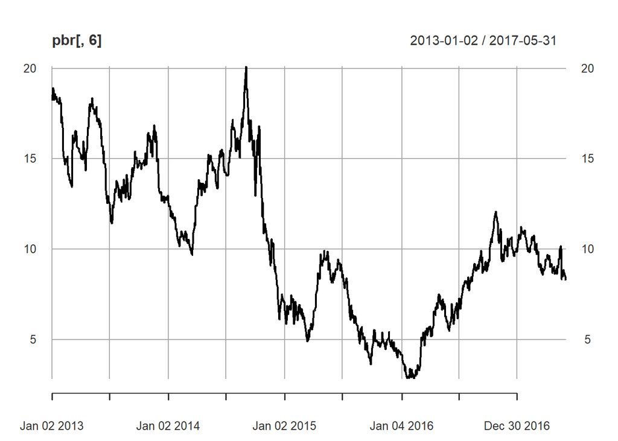

```r
plot(pbr[,6])
```

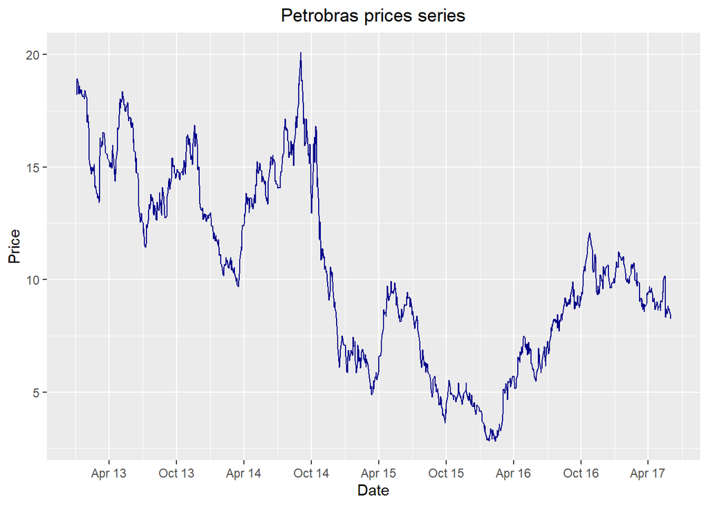

```r
ggplot(pbr,
       aes(x = index(pbr), y = pbr[,6])) +
  geom_line(color = "darkblue") +
  ggtitle("Petrobras prices series") +
  xlab("Date") +
  ylab("Price") +
  theme(plot.title = element_text(hjust = 0.5)) +
  scale_x_date(date_labels = "%b %y", date_breaks = "6 months")
```

We created this plot using the command `ggplot`. First, we use the object `pbr` as the series to be ploted. Then we indicate which elements will be in the axes:

- `index(pbr)`,
- the date in x-axis, and
- the adjusted price column, `pbr[,6]`, in y-axis.

Next, we add the element to be ploted, in this case, a blue line: `geom_line(color = "darkblue")`

Afterwards, we include the `title` and `names` of the axes, with the commands `ggtitle("Petrobras prices series")`, `xlab("Date")`, `ylab("Price")`.

By standard, the plot title is aligned to the left. To centralize it, the command `theme(plot.title = element_text(hjust = 0.5))` is used.

Lastly, to make the temporal axis more informative, we put the date tick at every 6 months in the format `mmm aa` using `scale_x_date(date_labels = "%b %y", date_breaks = "6 months")`.

In stocks analysis, a very used technique is the plot of `Moving Averages` in the prices graphs. A simple moving average is an arithmetic average from the last $q$ days from a $x_t$ series in the$t$ time period.

This indicator is interesting because it helps to identify **trends** and **smooths noises** from prices. That is, the bigger the days window for the MA calculation, smaller is the MA responsiveness to price variation.

> The smaller the window, the faster MA adapts itself to changes.

Now, we can calculate two moving averages for the stock prices series, one with 10 days window and the other with 30 days:

```r
pbr_mm <- subset(pbr, index(pbr) >= "2016-01-01")

pbr_mm10 <- rollmean(pbr_mm[,6], 10, fill = list(NA, NULL, NA), align = "right")
pbr_mm30 <- rollmean(pbr_mm[,6], 30, fill = list(NA, NULL, NA), align = "right")

pbr_mm$mm10 <- coredata(pbr_mm10)
pbr_mm$mm30 <- coredata(pbr_mm30)
```

First we subset the base for data since `2016` using the function `subset()`. Then, we use the function `rollmean()`, which takes as argument: the series $(x_t)$, in this case the adjusted price; the window of periods $(q)$; an optional fill argument, that is used to complete the days where it’s not possible to calculate the moving average, since the enough quantity of days hasn’t passed; the argument align indicates if the moving average should be calculated using the periods in the left, in the center or in the right of the $t$ day of the series. Lastly, we add the MA to two new columns in the initial database.

We calculated the two MA using 10 and 30 days of windows, filling the values with `NA` and using the periods in the left. Afterwards, we can plot both series in the same graphic of prices to identify trends. An existing theory in Technical Analysis is the one that when two MA of short and long term cross each other, there is an indication of buying or selling the stock. When the short term MA cross the long term upwards, there’s a buy a signal. When the opposite happens, there’s a sell signal.

Ploting the prices series and the moving averages for all days since `2016`:

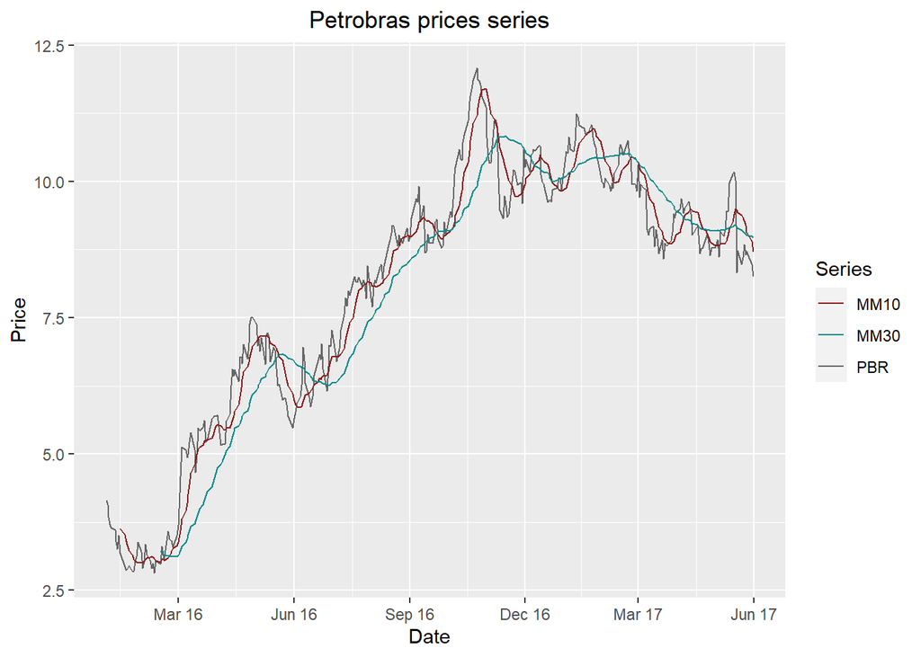

```r
ggplot(pbr_mm, aes(x = index(pbr_mm))) +
  geom_line(aes(y = pbr_mm[,6], color = "PBR")) + ggtitle("Petrobras prices series") +
  geom_line(aes(y = pbr_mm$mm10, color = "MM10")) +
  geom_line(aes(y = pbr_mm$mm30, color = "MM30")) + xlab("Date") + ylab("Price") +
  theme(plot.title = element_text(hjust = 0.5), panel.border = element_blank()) +
  scale_x_date(date_labels = "%b %y", date_breaks = "3 months") +
  scale_colour_manual("Series", values=c("PBR"="gray40", "MM10"="firebrick4", "MM30"="darkcyan"))
```

To create the graph, we plot the line of prices and the lines of moving averages. In this case, we plot each line differently, creating a kind of nickname for the color of each one. Then, we add the line scale_colour_manual, indicating the color of each nickname in order to make the color visible in the legend of the graph.

Verifying the plot, it’s possible to notice that there were 14 points in which the series crossed themselves and 1 point where they overlapped. Following the buy signal, we’d have been successful in 4 of 7 times. Following the sell indication, we’d have done right 5 in 7 times. In total, we’d be 9/14, that is 64% of success with a quite simple indicator. Of course this metric shouldn’d be used alone, many other informations should be considerated.

# 6 Returns

We have seen how the stock price has changed over time. Now we’ll verify how the stock return has behaved in the same period. To do this, we first need to create a new object with the calculated returns, using the adjusted prices column:

```r
pbr_ret <- diff(log(pbr[,6]))
pbr_ret <- pbr_ret[-1,]
```

What we’ve done here was using logarithm properties to calculate the log-return of the stock. That is:

$$\begin{eqnarray}
r_t & = & \log(1+R_t) \\
& = & \log\left(\frac{P_t}{P_{t-1}}\right) \\
& = & \log(P_t) - \log(P_{t-1})
\end{eqnarray}$$

The diff command calculates the difference of all values in any vector or element. With this, we only apply the difference to natural logarithms of stock prices.

In addition to this way, it’s possible to calculate returns differently. The package quantmod has some interesting functions to do this. Firstly, it’s really simple to select only one column of prices of each stock. For example:

```r
Op(pbr)
```

```
##            PBR.Open
## 2013-01-02    19.85
## 2013-01-03    19.64
## 2013-01-04    20.13
## 2013-01-07    20.08
## 2013-01-08    19.76
## 2013-01-09    19.56
## 2013-01-10    19.74
## 2013-01-11    19.84
## 2013-01-14    20.16
## 2013-01-15    19.88
## 2013-01-16    19.60
## 2013-01-17    19.85
## 2013-01-18    19.72
## 2013-01-22    19.19
## 2013-01-23    19.55
## 2013-01-24    19.60
## 2013-01-25    19.63
## 2013-01-28    19.88
## 2013-01-29    19.48
## 2013-01-30    18.74
## 2013-01-31    18.31
## 2013-02-01    18.68
## 2013-02-04    18.32
## 2013-02-05    17.17
## 2013-02-06    16.50
## 2013-02-07    16.92
## 2013-02-08    16.30
## 2013-02-11    16.20
## 2013-02-12    15.88
## 2013-02-13    16.23
## 2013-02-14    16.10
## 2013-02-15    16.09
## 2013-02-19    16.31
## 2013-02-20    16.31
## 2013-02-21    15.70
## 2013-02-22    15.33
## 2013-02-25    15.19
## 2013-02-26    14.72
## 2013-02-27    14.91
```

[output cut: 1057 more lines]

```
## 2017-05-10     9.58
## 2017-05-11     9.81
## 2017-05-12    10.09
## 2017-05-15    10.50
## 2017-05-16    10.46
## 2017-05-17    10.35
## 2017-05-18     8.47
## 2017-05-19     9.03
## 2017-05-22     8.72
## 2017-05-23     8.76
## 2017-05-24     8.95
## 2017-05-25     9.07
## 2017-05-26     8.74
## 2017-05-30     8.85
## 2017-05-31     8.67
```

```r
Cl(pbr)
```

```
##            PBR.Close
## 2013-01-02     19.60
## 2013-01-03     19.97
## 2013-01-04     20.37
## 2013-01-07     20.19
## 2013-01-08     19.66
## 2013-01-09     19.65
## 2013-01-10     20.01
## 2013-01-11     19.87
## 2013-01-14     19.70
## 2013-01-15     19.84
## 2013-01-16     19.75
## 2013-01-17     19.63
## 2013-01-18     19.53
## 2013-01-22     19.52
## 2013-01-23     19.41
## 2013-01-24     19.64
## 2013-01-25     19.81
## 2013-01-28     19.51
## 2013-01-29     19.49
## 2013-01-30     18.57
## 2013-01-31     18.28
## 2013-02-01     18.67
## 2013-02-04     18.03
## 2013-02-05     16.60
## 2013-02-06     16.50
## 2013-02-07     16.28
## 2013-02-08     16.18
## 2013-02-11     15.81
## 2013-02-12     16.06
## 2013-02-13     16.15
## 2013-02-14     16.11
## 2013-02-15     15.96
## 2013-02-19     16.29
## 2013-02-20     15.75
## 2013-02-21     15.19
## 2013-02-22     15.26
## 2013-02-25     14.91
## 2013-02-26     14.88
## 2013-02-27     14.90
```

[output cut: 1057 more lines]

```
## 2017-05-10      9.71
## 2017-05-11      9.70
## 2017-05-12     10.24
## 2017-05-15     10.41
## 2017-05-16     10.45
## 2017-05-17     10.29
## 2017-05-18      8.55
## 2017-05-19      8.96
## 2017-05-22      8.71
## 2017-05-23      8.83
## 2017-05-24      9.08
## 2017-05-25      8.89
## 2017-05-26      8.95
## 2017-05-30      8.70
## 2017-05-31      8.48
```

```r
Ad(pbr)
```

```
##            PBR.Adjusted
## 2013-01-02    18.208584
## 2013-01-03    18.552313
## 2013-01-04    18.923920
## 2013-01-07    18.756701
## 2013-01-08    18.264322
## 2013-01-09    18.255032
## 2013-01-10    18.589474
## 2013-01-11    18.459414
## 2013-01-14    18.301481
## 2013-01-15    18.431543
## 2013-01-16    18.347933
## 2013-01-17    18.236450
## 2013-01-18    18.143553
## 2013-01-22    18.134262
## 2013-01-23    18.032070
## 2013-01-24    18.245743
## 2013-01-25    18.403673
## 2013-01-28    18.124973
## 2013-01-29    18.106392
## 2013-01-30    17.251701
## 2013-01-31    16.982290
## 2013-02-01    17.344603
## 2013-02-04    16.750036
## 2013-02-05    15.421554
## 2013-02-06    15.328655
## 2013-02-07    15.124271
## 2013-02-08    15.031370
## 2013-02-11    14.687637
## 2013-02-12    14.919888
## 2013-02-13    15.003499
## 2013-02-14    14.966340
## 2013-02-15    14.826988
## 2013-02-19    15.133562
## 2013-02-20    14.631896
## 2013-02-21    14.111650
## 2013-02-22    14.176682
## 2013-02-25    13.851529
## 2013-02-26    13.823658
## 2013-02-27    13.842237
```

[output cut: 1057 more lines]

```
## 2017-05-10     9.455283
## 2017-05-11     9.445543
## 2017-05-12     9.971378
## 2017-05-15    10.136920
## 2017-05-16    10.175870
## 2017-05-17    10.020067
## 2017-05-18     8.325711
## 2017-05-19     8.724957
## 2017-05-22     8.481514
## 2017-05-23     8.598367
## 2017-05-24     8.841807
## 2017-05-25     8.656794
## 2017-05-26     8.715219
## 2017-05-30     8.471778
## 2017-05-31     8.257547
```

Each line will have as output the opening, closing and adjusted prices, respectively. The same accounts for other columns: `Hi()`, `Lo()` and `Vo()`, for maximum and minimum prices and volume of transactions.

For the returns, we simply adapt and define which columns will be used, for example: `ClCl()` will give us the returns using the closing prices from two periods; `OpCl()` will result in the return from the closing price over the opening price from the same day.

Another interesting possibility given by quantmod is the calculation of returns for different periods. For example, it’s possible to calculate the returns by day, week, month, quarter and year, just by using the following commands:

```r
dailyReturn(pbr)
```

```
##            daily.returns
## 2013-01-02 -0.0125944584
## 2013-01-03  0.0188775000
## 2013-01-04  0.0200301462
## 2013-01-07 -0.0088365239
## 2013-01-08 -0.0262506673
## 2013-01-09 -0.0005086470
## 2013-01-10  0.0183206107
## 2013-01-11 -0.0069964518
## 2013-01-14 -0.0085556110
## 2013-01-15  0.0071065479
## 2013-01-16 -0.0045362903
## 2013-01-17 -0.0060760000
## 2013-01-18 -0.0050941419
## 2013-01-22 -0.0005120839
## 2013-01-23 -0.0056352459
## 2013-01-24  0.0118495106
## 2013-01-25  0.0086558049
## 2013-01-28 -0.0151438170
## 2013-01-29 -0.0010251153
## 2013-01-30 -0.0472036942
## 2013-01-31 -0.0156165320
## 2013-02-01  0.0213347363
## 2013-02-04 -0.0342795394
## 2013-02-05 -0.0793123084
## 2013-02-06 -0.0060240964
## 2013-02-07 -0.0133332727
## 2013-02-08 -0.0061425672
## 2013-02-11 -0.0228677379
## 2013-02-12  0.0158127135
## 2013-02-13  0.0056040477
## 2013-02-14 -0.0024767183
## 2013-02-15 -0.0093110485
## 2013-02-19  0.0206767544
## 2013-02-20 -0.0331492306
## 2013-02-21 -0.0355555556
## 2013-02-22  0.0046082949
## 2013-02-25 -0.0229357798
## 2013-02-26 -0.0020120724
## 2013-02-27  0.0013440860
```

[output cut: 1057 more lines]

```
## 2017-05-10  0.0373931624
## 2017-05-11 -0.0010298661
## 2017-05-12  0.0556701031
## 2017-05-15  0.0166015625
## 2017-05-16  0.0038424592
## 2017-05-17 -0.0153110048
## 2017-05-18 -0.1690962099
## 2017-05-19  0.0479532164
## 2017-05-22 -0.0279017857
## 2017-05-23  0.0137772675
## 2017-05-24  0.0283125708
## 2017-05-25 -0.0209251101
## 2017-05-26  0.0067491564
## 2017-05-30 -0.0279329609
## 2017-05-31 -0.0252873563
```

```r
weeklyReturn(pbr)
```

```
##            weekly.returns
## 2013-01-04   0.0261965239
## 2013-01-11  -0.0245458996
## 2013-01-18  -0.0171112221
## 2013-01-25   0.0143368144
## 2013-02-01  -0.0575466460
## 2013-02-08  -0.1333690412
## 2013-02-15  -0.0135970334
## 2013-02-22  -0.0438596491
## 2013-03-01  -0.0321100917
## 2013-03-08   0.1638457007
## 2013-03-15   0.0360673626
## 2013-03-22  -0.0539022490
## 2013-03-28  -0.0166172107
## 2013-04-05  -0.0120699457
## 2013-04-12   0.0134391562
## 2013-04-19  -0.0042194093
## 2013-04-26   0.0914044189
## 2013-05-03   0.0532445339
## 2013-05-10  -0.0063190627
## 2013-05-17  -0.0074192365
## 2013-05-24  -0.0282967966
## 2013-05-31  -0.0236264273
## 2013-06-07  -0.0630275746
## 2013-06-14  -0.0606606607
## 2013-06-21  -0.1176470588
## 2013-06-28  -0.0282608696
## 2013-07-05  -0.0865026100
## 2013-07-12   0.0653061224
## 2013-07-19   0.0697318008
## 2013-07-26   0.0358166189
## 2013-08-02  -0.0235131397
## 2013-08-09   0.0113314448
## 2013-08-16   0.0105042017
## 2013-08-23   0.0381150381
## 2013-08-30  -0.0974632844
## 2013-09-06   0.0850591716
## 2013-09-13   0.0293115201
## 2013-09-20   0.0556291391
## 2013-09-27  -0.0338770389
```

[output cut: 177 more lines]

```
## 2017-02-24  -0.0510677809
## 2017-03-03  -0.0009784736
## 2017-03-10  -0.0812928501
## 2017-03-17  -0.0501066098
## 2017-03-24   0.0168350168
## 2017-03-31   0.0695364238
## 2017-04-07   0.0072239422
## 2017-04-13  -0.0512295082
## 2017-04-21  -0.0269978402
## 2017-04-28   0.0000000000
## 2017-05-05   0.0344062153
## 2017-05-12   0.0987124464
## 2017-05-19  -0.1250000000
## 2017-05-26  -0.0011160714
## 2017-05-31  -0.0525139665
```

```r
monthlyReturn(pbr)
```

```
##            monthly.returns
## 2013-01-31   -0.0790931486
## 2013-02-28   -0.1974836325
## 2013-03-28    0.1295160191
## 2013-04-30    0.1557030779
## 2013-05-31   -0.0720626632
## 2013-06-28   -0.2453573438
## 2013-07-31    0.0171513796
## 2013-08-30   -0.0087976540
## 2013-09-30    0.1457100592
## 2013-10-31    0.1252420917
## 2013-11-29   -0.0854847963
## 2013-12-31   -0.1355081556
## 2014-01-31   -0.1865021771
## 2014-02-28   -0.0008920607
## 2014-03-31    0.1741071429
## 2014-04-30    0.0555133080
## 2014-05-30    0.0158501441
## 2014-06-30    0.0375886525
## 2014-07-31    0.0895420369
## 2014-08-29    0.2277289837
## 2014-09-30   -0.2749105774
## 2014-10-31   -0.1754756871
## 2014-11-28   -0.1692307692
## 2014-12-31   -0.2489711934
## 2015-01-30   -0.1767123288
## 2015-02-27    0.1031613977
## 2015-03-31   -0.0935143288
## 2015-04-30    0.5806988353
## 2015-05-29   -0.1210526316
## 2015-06-30    0.0838323353
## 2015-07-31   -0.2486187845
## 2015-08-31   -0.1382352941
## 2015-09-30   -0.2576791809
## 2015-10-30    0.1218390805
## 2015-11-30   -0.0225409836
## 2015-12-31   -0.0985324948
## 2016-01-29   -0.1930232558
## 2016-02-29    0.0374639769
## 2016-03-31    0.6222222222
## 2016-04-29    0.3202054795
## 2016-05-31   -0.2697795071
## 2016-06-30    0.2717584369
## 2016-07-29    0.2122905028
## 2016-08-31    0.0529953917
## 2016-09-30    0.0207877462
## 2016-10-31    0.2508038585
## 2016-11-30   -0.0685518423
## 2016-12-30   -0.0699172033
## 2017-01-31    0.0148367953
## 2017-02-28   -0.0175438596
## 2017-03-31   -0.0386904762
## 2017-04-28   -0.0701754386
## 2017-05-31   -0.0588235294
```

```r
quarterlyReturn(pbr)
```

```
##            quarterly.returns
## 2013-03-28       -0.16523929
## 2013-06-28       -0.19070610
## 2013-09-30        0.15510813
## 2013-12-31       -0.11039380
## 2014-03-31       -0.04571843
## 2014-06-30        0.11254753
## 2014-09-30       -0.03007519
## 2014-12-31       -0.48555321
## 2015-03-31       -0.17671233
## 2015-06-30        0.50582363
## 2015-09-30       -0.51933702
## 2015-12-31       -0.01149425
## 2016-03-31        0.35813953
## 2016-06-30        0.22602740
## 2016-09-30        0.30307263
## 2016-12-30        0.08360129
## 2017-03-31       -0.04154303
## 2017-05-31       -0.12487100
```

```r
yearlyReturn(pbr)
```

```
##            yearly.returns
## 2013-12-31     -0.3057935
## 2014-12-31     -0.4702467
## 2015-12-31     -0.4109589
## 2016-12-30      1.3511628
## 2017-05-31     -0.1612265
```

All these commands make the analysis and the calculation much faster and simpler to do.

Now, we proceed to verify some basic statistics from Petrobras returns.

```r
summary(pbr_ret)
```

```
##      Index             PBR.Adjusted
##  Min.   :2013-01-03   Min.   :-0.1852413
##  1st Qu.:2014-02-10   1st Qu.:-0.0209233
##  Median :2015-03-18   Median :-0.0005546
##  Mean   :2015-03-18   Mean   :-0.0007124
##  3rd Qu.:2016-04-24   3rd Qu.: 0.0177905
##  Max.   :2017-05-31   Max.   : 0.1555104
```

```r
sd(pbr_ret)
```

```
## [1] 0.03711175
```

This indicates that in average the stock hasn’t performed well. Now we can plot the returns and see how they’ve done over time:

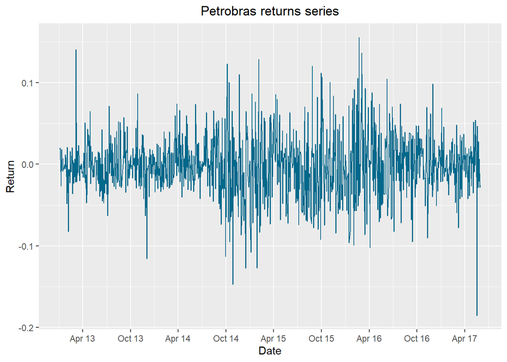

```r
ggplot(pbr_ret, aes(x = index(pbr_ret), y = pbr_ret)) +
  geom_line(color = "deepskyblue4") +
  ggtitle("Petrobras returns series") +
  xlab("Date") + ylab("Return") +
  theme(plot.title = element_text(hjust = 0.5)) +
  scale_x_date(date_labels = "%b %y", date_breaks = "6 months")
```

To plot this last graph, we used the same parameters of the prices graph, changing only the line color.

Making a brief analysis of the graphic, it is possible to see that the smallest return of the series happened around may. More specifically, in may 18, one day after the news release with recordings of brazilian president Michel Temer. In the audios, he agreed to give payments in exchange of silence from arrested politicians. This fact strongly impacted the stocks market, specially brazilian and public companies, like Petrobras.

Now let’s take a small look at the stock returns in `2017`:

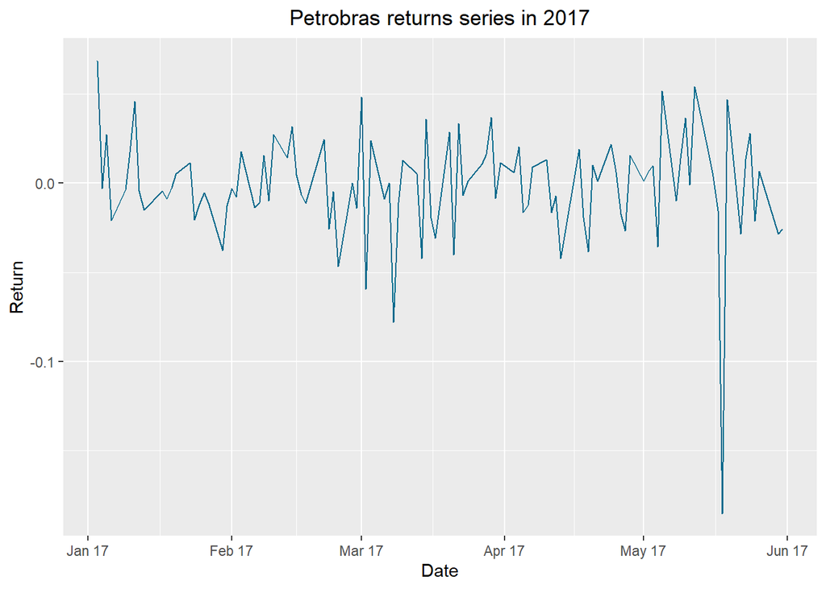

```r
pbr_ret17 <- subset(pbr_ret, index(pbr_ret) > "2017-01-01")

ggplot(pbr_ret17, aes(x = index(pbr_ret17), y = pbr_ret17)) +
  geom_line(color = "deepskyblue4") +
  ggtitle("Petrobras returns series in 2017") +
  xlab("Date") +
  ylab("Return") +
  theme(plot.title = element_text(hjust = 0.5)) +
  scale_x_date(date_labels = "%b %y", date_breaks = "1 months")
```

```r
summary(pbr_ret17)
```

```
##      Index             PBR.Adjusted
##  Min.   :2017-01-03   Min.   :-0.185241
##  1st Qu.:2017-02-08   1st Qu.:-0.014350
##  Median :2017-03-17   Median :-0.002689
##  Mean   :2017-03-17   Mean   :-0.001707
##  3rd Qu.:2017-04-24   3rd Qu.: 0.014976
##  Max.   :2017-05-31   Max.   : 0.068795
```

```r
sd(pbr_ret17)
```

```
## [1] 0.03089103
```

We separated in an object all of the returns from `2017`, using the function `subset()`. With this, the descriptive statistics still suggest a negative average return. In other hand, the standard deviation is smaller, which indicates smaller risk. Furthermore, this negative return is given by, in majority, by the big fall in the day 18.